# Overview:

### Random Forests

```
Accuracy on training set :  1.0
Accuracy on test set :  0.9004771642808452
Recall on training set :  1.0
Recall on test set :  0.5217391304347826
Precision on training set :  1.0
Precision on test set :  0.9113924050632911
```

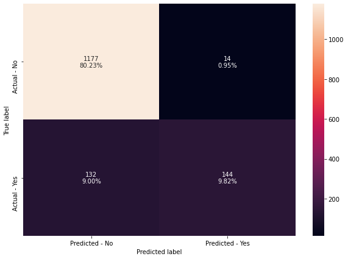

```python
#Fitting the model
rf_estimator = RandomForestClassifier(random_state=1)
rf_estimator.fit(X_train,y_train)

#Calculating different metrics
get_metrics_score(rf_estimator)

#Creating confusion matrix
make_confusion_matrix(rf_estimator,y_test)
```

### Tuning Random Forests

```python
# Choose the type of classifier.
rf_estimator_weighted = RandomForestClassifier(random_state=1)

# Grid of parameters to choose from
## add from article
parameters = {
    "class_weight": [{0: 0.2, 1: 0.8}],
    "n_estimators": [100,150,200,250],
    "min_samples_leaf": np.arange(5, 10),
    "max_features": np.arange(0.2, 0.7, 0.1),
    "max_samples": np.arange(0.3, 0.7, 0.1),
}

# Type of scoring used to compare parameter combinations
acc_scorer = metrics.make_scorer(metrics.recall_score)

# Run the grid search
grid_obj = GridSearchCV(rf_estimator_weighted, parameters, scoring=acc_scorer,cv=5)
grid_obj = grid_obj.fit(X_train, y_train)

# Set the clf to the best combination of parameters
rf_estimator_weighted = grid_obj.best_estimator_

# Fit the best algorithm to the data.
rf_estimator_weighted.fit(X_train, y_train)
```

```
RandomForestClassifier(class_weight={0: 0.2, 1: 0.8}, max_features=0.2,
                       max_samples=0.6000000000000001, min_samples_leaf=9,
                       n_estimators=150, random_state=1)
```

```
Accuracy on training set :  0.8757673194972231
Accuracy on test set :  0.858214042263122
Recall on training set :  0.7577639751552795
Recall on test set :  0.6485507246376812
Precision on training set :  0.6446499339498019
Precision on test set :  0.6172413793103448
```

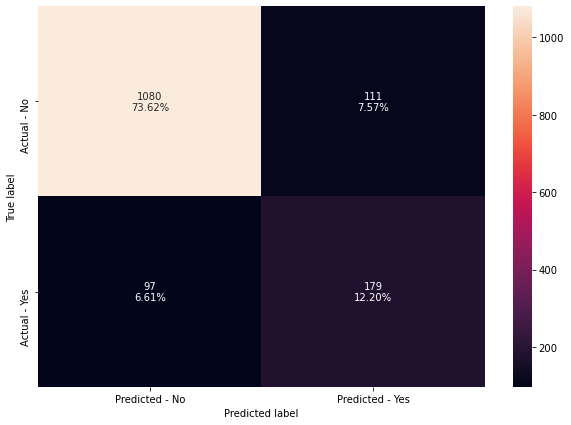

```python
#Using above defined function to get accuracy, recall and precision on train and test set
rf_estimator_weighted_score=get_metrics_score(rf_estimator_weighted)

make_confusion_matrix(rf_estimator_weighted,y_test)
```

Observations:

### AdaBoost Classifier

```
Accuracy on training set :  0.8488745980707395
Accuracy on test set :  0.8438991138377642
Recall on training set :  0.3338509316770186
Recall on test set :  0.3188405797101449
Precision on training set :  0.7095709570957096
Precision on test set :  0.6821705426356589
```

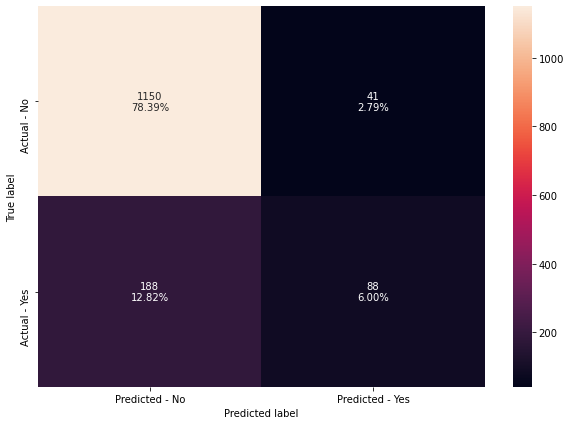

```python
#Fitting the model
ab_classifier = AdaBoostClassifier(random_state=1)
ab_classifier.fit(X_train,y_train)

#Calculating different metrics
get_metrics_score(ab_classifier)

#Creating confusion matrix
make_confusion_matrix(ab_classifier,y_test)
```

### Hyperparameter Tuning

```python
# Choose the type of classifier.
abc_tuned = AdaBoostClassifier(random_state=1)

# Grid of parameters to choose from
parameters = {
    #Let's try different max_depth for base_estimator
    "base_estimator":[DecisionTreeClassifier(max_depth=1),DecisionTreeClassifier(max_depth=2),
                      DecisionTreeClassifier(max_depth=3)],
    "n_estimators": np.arange(10,110,10),
    "learning_rate":np.arange(0.1,2,0.1)
}

# Type of scoring used to compare parameter  combinations
scorer = metrics.make_scorer(metrics.recall_score)

# Run the grid search
grid_obj = GridSearchCV(abc_tuned, parameters, scoring=scorer,cv=5)
grid_obj = grid_obj.fit(X_train, y_train)

# Set the clf to the best combination of parameters
abc_tuned = grid_obj.best_estimator_

# Fit the best algorithm to the data.
abc_tuned.fit(X_train, y_train)
```

```
AdaBoostClassifier(base_estimator=DecisionTreeClassifier(max_depth=3),
                   learning_rate=1.7000000000000002, n_estimators=100,
                   random_state=1)
```

```
Accuracy on training set :  0.9777842736042093
Accuracy on test set :  0.8554873892297206
Recall on training set :  0.9270186335403726
Recall on test set :  0.6268115942028986
Precision on training set :  0.9536741214057508
Precision on test set :  0.6134751773049646
```

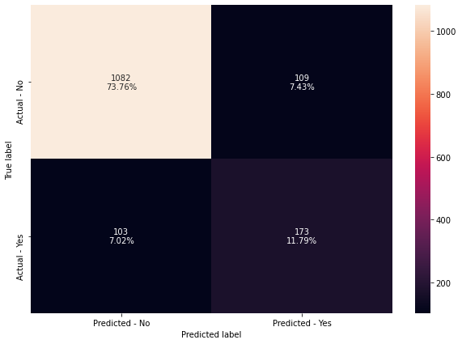

```python
#Calculating different metrics
get_metrics_score(abc_tuned)

#Creating confusion matrix
make_confusion_matrix(abc_tuned,y_test)
```

Observations:

1. The recall score on the first AdaBoost model is very low with 33%.
2. The recall score on teh hypertuned model is much better but is still low with 62% as it is with other models.
3. There is overfitting visible in the hypertuned model with teh huge discrepency in the recall score at 92% and 62%

### Gradient Boosting Classifier

```
Accuracy on training set :  0.8851213095586086
Accuracy on test set :  0.858214042263122
Recall on training set :  0.4409937888198758
Recall on test set :  0.358695652173913
Precision on training set :  0.8958990536277602
Precision on test set :  0.7615384615384615
```

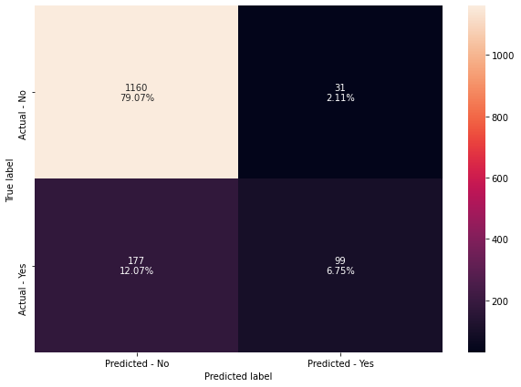

```python
#Fitting the model
gb_classifier = GradientBoostingClassifier(random_state=1)
gb_classifier.fit(X_train,y_train)

#Calculating different metrics
get_metrics_score(gb_classifier)

#Creating confusion matrix
make_confusion_matrix(gb_classifier,y_test)
```

### Hyperparameter Tuning

```python
# Choose the type of classifier.
gbc_tuned = GradientBoostingClassifier(init=AdaBoostClassifier(random_state=1),random_state=1)

# Grid of parameters to choose from
parameters = {
    "n_estimators": [100,150,200,250],
    "subsample":[0.8,0.9,1],
    "max_features":[0.7,0.8,0.9,1]
}

# Type of scoring used to compare parameter combinations
scorer = metrics.make_scorer(metrics.recall_score)

# Run the grid search
grid_obj = GridSearchCV(gbc_tuned, parameters, scoring=scorer,cv=5)
grid_obj = grid_obj.fit(X_train, y_train)

# Set the clf to the best combination of parameters
gbc_tuned = grid_obj.best_estimator_

# Fit the best algorithm to the data.
gbc_tuned.fit(X_train, y_train)
```

```
GradientBoostingClassifier(init=AdaBoostClassifier(random_state=1),
                           max_features=0.8, n_estimators=250, random_state=1,
                           subsample=0.9)
```

```
Accuracy on training set :  0.9237065185618241
Accuracy on test set :  0.8793456032719836
Recall on training set :  0.6335403726708074
Recall on test set :  0.4782608695652174
Precision on training set :  0.9422632794457275
Precision on test set :  0.8
```

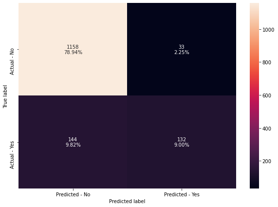

```python
#Calculating different metrics
get_metrics_score(gbc_tuned)

#Creating confusion matrix
make_confusion_matrix(gbc_tuned,y_test)
```

Observations:

### XGBoost Classifier

```
Accuracy on training set :  0.9988307512423268
Accuracy on test set :  0.9134287661895024
Recall on training set :  0.9937888198757764
Recall on test set :  0.6340579710144928
Precision on training set :  1.0
Precision on test set :  0.8706467661691543
```

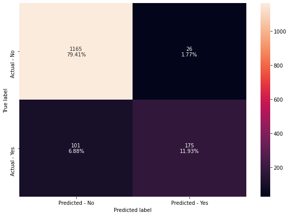

```python
#Fitting the model
xgb_classifier = XGBClassifier(random_state=1, eval_metric='logloss')
xgb_classifier.fit(X_train,y_train)

#Calculating different metrics
get_metrics_score(xgb_classifier)

#Creating confusion matrix
make_confusion_matrix(xgb_classifier,y_test)
```

### Hyperparameter Tuning

```python
# Choose the type of classifier.
xgb_tuned = XGBClassifier(random_state=1, eval_metric='logloss')

# Grid of parameters to choose from
parameters = {
    "n_estimators": [10,30,50],
    "scale_pos_weight":[1,2,5],
    "subsample":[0.7,0.9,1],
    "learning_rate":[0.05, 0.1,0.2],
    "colsample_bytree":[0.7,0.9,1],
    "colsample_bylevel":[0.5,0.7,1]
}

# Type of scoring used to compare parameter combinations
scorer = metrics.make_scorer(metrics.recall_score)

# Run the grid search
grid_obj = GridSearchCV(xgb_tuned, parameters,scoring=scorer,cv=5)
grid_obj = grid_obj.fit(X_train, y_train)

# Set the clf to the best combination of parameters
xgb_tuned = grid_obj.best_estimator_

# Fit the best algorithm to the data.
xgb_tuned.fit(X_train, y_train)
```

```
XGBClassifier(base_score=0.5, booster='gbtree', colsample_bylevel=1,
              colsample_bynode=1, colsample_bytree=0.9, eval_metric='logloss',
              gamma=0, gpu_id=-1, importance_type='gain',
              interaction_constraints='', learning_rate=0.1, max_delta_step=0,
              max_depth=6, min_child_weight=1, missing=nan,
              monotone_constraints='()', n_estimators=50, n_jobs=8,
              num_parallel_tree=1, random_state=1, reg_alpha=0, reg_lambda=1,
              scale_pos_weight=5, subsample=0.9, tree_method='exact',
              validate_parameters=1, verbosity=None)
```

```
Accuracy on training set :  0.9301373867290266
Accuracy on test set :  0.8698023176550784
Recall on training set :  0.9611801242236024
Recall on test set :  0.7898550724637681
Precision on training set :  0.7430972388955582
Precision on test set :  0.6210826210826211
```

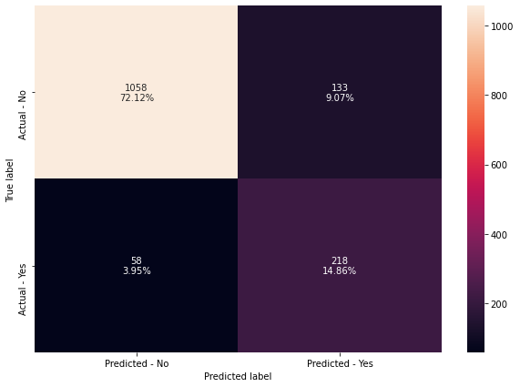

```python
#Calculating different metrics
get_metrics_score(xgb_tuned)

#Creating confusion matrix
make_confusion_matrix(xgb_tuned,y_test)
```

Observation:

1. There appears to be overfitting in the XGboost model as there is discrepency between the test and train data set.
2. The best recall score is visible in the hypertuned XGboost model with 78%, which overall is a good score.

## Stacking Classifier

```python
estimators = [('Random Forest',rf_estimator_weighted), ('Gradient Boosting',gbc_tuned), ('Decision Tree',dtree_estimator)]

final_estimator = xgb_tuned

stacking_classifier= StackingClassifier(estimators=estimators,final_estimator=final_estimator)

stacking_classifier.fit(X_train,y_train)
```

```
StackingClassifier(estimators=[('Random Forest',
                                RandomForestClassifier(class_weight={0: 0.2,
                                                                     1: 0.8},
                                                       max_features=0.2,
                                                       max_samples=0.6000000000000001,
                                                       min_samples_leaf=9,
                                                       n_estimators=150,
                                                       random_state=1)),
                               ('Gradient Boosting',
                                GradientBoostingClassifier(init=AdaBoostClassifier(random_state=1),
                                                           max_features=0.8,
                                                           n_estimators=250,
                                                           random_state=1,
                                                           subsample=0.9)),...
                                                 eval_metric='logloss', gamma=0,
                                                 gpu_id=-1,
                                                 importance_type='gain',
                                                 interaction_constraints='',
                                                 learning_rate=0.1,
                                                 max_delta_step=0, max_depth=6,
                                                 min_child_weight=1,
                                                 missing=nan,
                                                 monotone_constraints='()',
                                                 n_estimators=50, n_jobs=8,
                                                 num_parallel_tree=1,
                                                 random_state=1, reg_alpha=0,
                                                 reg_lambda=1,
                                                 scale_pos_weight=5,
                                                 subsample=0.9,
                                                 tree_method='exact',
                                                 validate_parameters=1,
                                                 verbosity=None))
```

```
Accuracy on training set :  0.8842443729903537
Accuracy on test set :  0.8323108384458078
Recall on training set :  0.9285714285714286
Recall on test set :  0.8333333333333334
Precision on training set :  0.630801687763713
Precision on test set :  0.5348837209302325
```

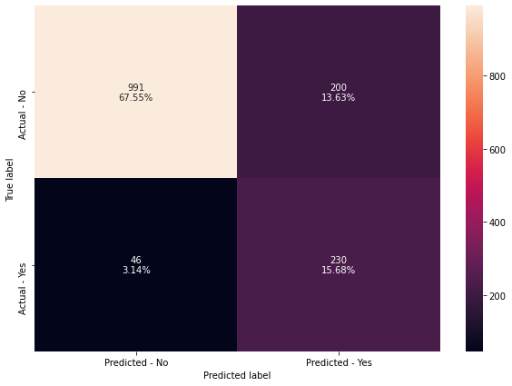

```python
#Calculating different metrics
get_metrics_score(stacking_classifier)

#Creating confusion matrix
make_confusion_matrix(stacking_classifier,y_test)
```

Observation:

1. The Stacking classifier has showed great results compared to any other model.
2. There does not appear to be any over fitting between the train and test data.
3. The recall score on the stacking classifier is about 83%, which is overall a good score for the model.

### Feature Importances

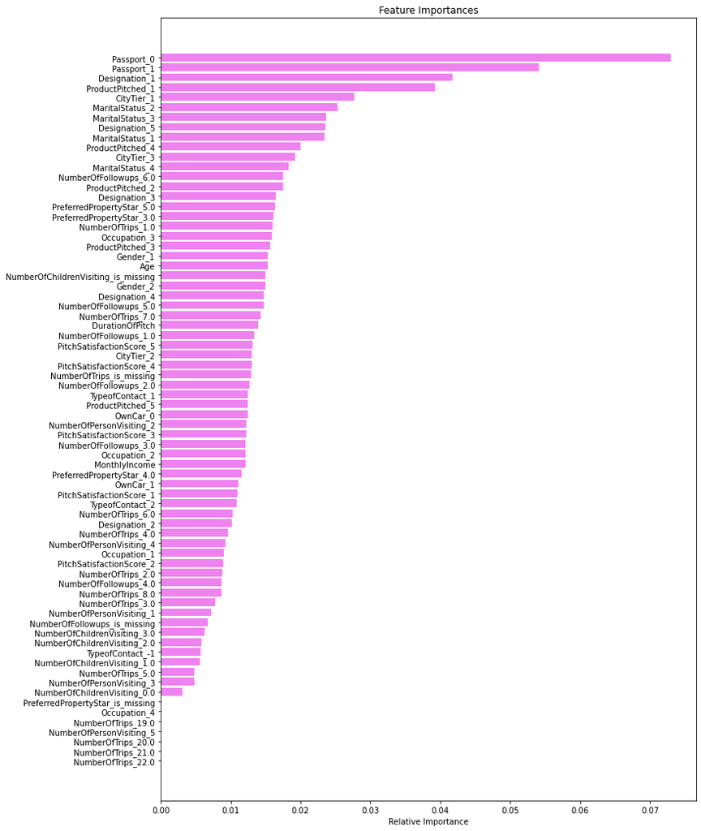

```python
feature_names = X_train.columns
importances = xgb_tuned.feature_importances_
indices = np.argsort(importances)

plt.figure(figsize=(12,18))
plt.title('Feature Importances')
plt.barh(range(len(indices)), importances[indices], color='violet', align='center')
plt.yticks(range(len(indices)), [feature_names[i] for i in indices])
plt.xlabel('Relative Importance')
plt.show()
```

Observation:

1. The most important variable is the avaiablity of Passport. Not having passport has the highest importance from all the variables.
2. Least important variable seems to be the Number of trips.

```python
# defining list of models
models = [d_tree, dtree_estimator,rf_estimator, rf_estimator_weighted, bagging_estimator,bagging_estimator_tuned,
          ab_classifier, abc_tuned, gb_classifier, gbc_tuned, xgb_classifier,xgb_tuned, stacking_classifier]

# defining empty lists to add train and test results
acc_train = []
acc_test = []
recall_train = []
recall_test = []
precision_train = []
precision_test = []
f1_train = []
f1_test = []

# looping through all the models to get the metrics score - Accuracy, Recall and Precision
for model in models:

    j = get_metrics_score(model,False)
    acc_train.append(j[0])
    acc_test.append(j[1])
    recall_train.append(j[2])
    recall_test.append(j[3])
    precision_train.append(j[4])
    precision_test.append(j[5])
```

```python
comparison_frame = pd.DataFrame({'Model':['Decision Tree','Tuned Decision Tree','Random Forest','Tuned Random Forest',
                                          'Bagging Classifier','Bagging Classifier Tuned','AdaBoost Classifier','Tuned AdaBoost Classifier',
                                          'Gradient Boosting Classifier', 'Tuned Gradient Boosting Classifier',
                                          'XGBoost Classifier',  'Tuned XGBoost Classifier', 'Stacking Classifier'],
                                          'Train_Accuracy': acc_train,'Test_Accuracy': acc_test,
                                          'Train_Recall':recall_train,'Test_Recall':recall_test,
                                          'Train_Precision':precision_train,'Test_Precision':precision_test})

#Sorting models in decreasing order of test recall
comparison_frame
```

|  | Model | Train_Accuracy | Test_Accuracy | Train_Recall | Test_Recall | Train_Precision | Test_Precision |
| --- | --- | --- | --- | --- | --- | --- | --- |
| 0 | Decision Tree | 1.000000 | 0.891616 | 1.000000 | 0.688406 | 1.000000 | 0.722433 |
| 1 | Tuned Decision Tree | 0.786320 | 0.793456 | 0.663043 | 0.681159 | 0.453773 | 0.466501 |
| 2 | Random Forest | 1.000000 | 0.900477 | 1.000000 | 0.521739 | 1.000000 | 0.911392 |
| 3 | Tuned Random Forest | 0.875767 | 0.858214 | 0.757764 | 0.648551 | 0.644650 | 0.617241 |
| 4 | Bagging Classifier | 0.994154 | 0.916155 | 0.972050 | 0.626812 | 0.996815 | 0.896373 |
| 5 | Bagging Classifier Tuned | 0.999415 | 0.928425 | 0.996894 | 0.663043 | 1.000000 | 0.938462 |
| 6 | AdaBoost Classifier | 0.848875 | 0.843899 | 0.333851 | 0.318841 | 0.709571 | 0.682171 |
| 7 | Tuned AdaBoost Classifier | 0.977784 | 0.855487 | 0.927019 | 0.626812 | 0.953674 | 0.613475 |
| 8 | Gradient Boosting Classifier | 0.885121 | 0.858214 | 0.440994 | 0.358696 | 0.895899 | 0.761538 |
| 9 | Tuned Gradient Boosting Classifier | 0.923707 | 0.879346 | 0.633540 | 0.478261 | 0.942263 | 0.800000 |
| 10 | XGBoost Classifier | 0.998831 | 0.913429 | 0.993789 | 0.634058 | 1.000000 | 0.870647 |
| 11 | Tuned XGBoost Classifier | 0.930137 | 0.869802 | 0.961180 | 0.789855 | 0.743097 | 0.621083 |
| 12 | Stacking Classifier | 0.884244 | 0.832311 | 0.928571 | 0.833333 | 0.630802 | 0.534884 |

Observations:

1. From the overall models all models have good accuracy scores.
2. But since the focus is on the recall scores, the best recall score is shown by the Tumned XGboost classifier and the Stacking classifier.
3. For feature importance as the Stacking classifier does not have that feature Tuned XGboost classifier has been used.

# Conclusion:

1. From the EDA it was found out that on average lower aged, higher product time pitched and lower income individuals were more likely to opt for the product.
2. Most clients were from tier 1 cities, arrived with self-enquiry, was on an executive and salaried individuals that were more likely to opt for the product.
3. Males that are married, with passports, with 2 number of trips were more likely to opt for the basic type of travel package.
4. Now to enhance the customer base it is needed to not lose those customers who are actually willing to buy the package but they are predicted that they will not buy the package. These are false-negative cases. Now to hold these customers we need to reduce the FN as much as possible. As a consequence, the recall has to increase. Due to this, the recall is selected as a performance metric.
5. 13 different types of models were used, from Decision tree, random forest, bagging classifier, Adaboost, gradient boosting, XGboost and Stacking classifier with thier respective hypertuned models were used.
6. The best model from all the models were found out to be the stacking classifier and the tuned XGboost classifier that had the following recall scores 83% and 78% respectively.
7. The two scores listed above are good indication of the good models predicted by the two classifiers.
8. For feature importance, tuned XGboost classifier was chosen, and the most important features were the clients not having a passport and the designation they held. While the least important feature Number of Trips and Occupation.

# Recommendation:

1. I would recommend to market individuals that are lower aged, lower income, from tier 1 cities, arrived with self-enquirt, works on an exectutive postion that are salaried. Markting towards males that are married that have passports are more likely to enquire about the basic travel package offered.
2. Most sought out travel package is the basic travel package.
3. Not having a passport is one of the main features that needs to be considered.
4. The best model from all the models were found out to be the stacking classifier and the tuned XGboost classifier that had the following recall scores 83% and 78% respectively. The two scores listed above are good indication of the good models predicted by the two classifiers.For feature importance, tuned XGboost classifier was chosen, and the most important features were the clients not having a passport and the designation they held. While the least important feature Number of Trips and Occupation.